# Lab №2

Let's first read the data and prepare a Dataframe

```python
import pandas as pd
import matplotlib.pyplot as plt
import seaborn as sns
import pyreadr

classification_code = pyreadr.read_r('Data/Source_Classification_Code.rds')
summary = pyreadr.read_r('Data/summarySCC_PM25.rds')
```

```python
df_class = classification_code[None]
print(type(df_class))
print(df_class.columns)
print(df_class.head())
```

```
<class 'pandas.core.frame.DataFrame'>
Index(['SCC', 'Data.Category', 'Short.Name', 'EI.Sector', 'Option.Group',
       'Option.Set', 'SCC.Level.One', 'SCC.Level.Two', 'SCC.Level.Three',
       'SCC.Level.Four', 'Map.To', 'Last.Inventory.Year', 'Created_Date',
       'Revised_Date', 'Usage.Notes'],
      dtype='object')
        SCC Data.Category                                         Short.Name
0  10100101         Point  Ext Comb /Electric Gen /Anthracite Coal /Pulve...  \
1  10100102         Point  Ext Comb /Electric Gen /Anthracite Coal /Trave...
2  10100201         Point  Ext Comb /Electric Gen /Bituminous Coal /Pulve...
3  10100202         Point  Ext Comb /Electric Gen /Bituminous Coal /Pulve...
4  10100203         Point  Ext Comb /Electric Gen /Bituminous Coal /Cyclo...

                                EI.Sector Option.Group Option.Set
0  Fuel Comb - Electric Generation - Coal                          \
1  Fuel Comb - Electric Generation - Coal
2  Fuel Comb - Electric Generation - Coal
3  Fuel Comb - Electric Generation - Coal
4  Fuel Comb - Electric Generation - Coal

                 SCC.Level.One        SCC.Level.Two
0  External Combustion Boilers  Electric Generation  \
1  External Combustion Boilers  Electric Generation
2  External Combustion Boilers  Electric Generation
3  External Combustion Boilers  Electric Generation
4  External Combustion Boilers  Electric Generation

                 SCC.Level.Three
0                Anthracite Coal  \
1                Anthracite Coal
2  Bituminous/Subbituminous Coal
3  Bituminous/Subbituminous Coal
4  Bituminous/Subbituminous Coal

                                  SCC.Level.Four  Map.To Last.Inventory.Year
0                                Pulverized Coal     NaN                 NaN  \
1              Traveling Grate (Overfeed) Stoker     NaN                 NaN
2  Pulverized Coal: Wet Bottom (Bituminous Coal)     NaN                 NaN
3  Pulverized Coal: Dry Bottom (Bituminous Coal)     NaN                 NaN
4              Cyclone Furnace (Bituminous Coal)     NaN                 NaN

  Created_Date Revised_Date Usage.Notes
0
1
2
3
4
```

```python
df_summary = summary[None]
print(df_summary.head())
```

```
           fips       SCC Pollutant  Emissions   type  year
rownames
4         09001  10100401  PM25-PRI     15.714  POINT  1999
8         09001  10100404  PM25-PRI    234.178  POINT  1999
12        09001  10100501  PM25-PRI      0.128  POINT  1999
16        09001  10200401  PM25-PRI      2.036  POINT  1999
20        09001  10200504  PM25-PRI      0.388  POINT  1999
```

## Task 1:

Have total emissions from PM2.5 decreased in the United States from 1999 to 2008? Make a plot showing the total PM2.5 emission from all sources for each of the years 1999, 2002, 2005, and 2008.

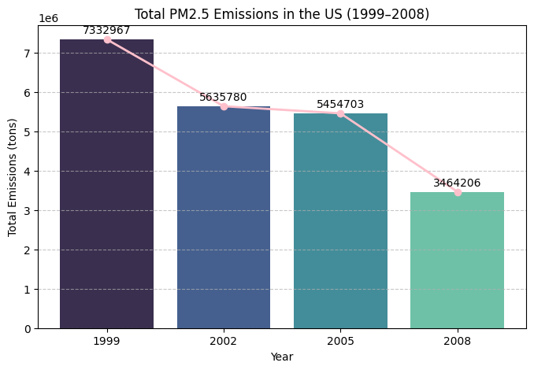

```python
total_emissions = df_summary.groupby("year")["Emissions"].sum().reset_index()

def plot_emissions_bars(data, title=''):
    plt.figure(figsize=(8, 5))
    ax = sns.barplot(data=data, x="year", y="Emissions", palette="mako")

    for p in ax.containers:
        ax.bar_label(p, fmt="%.0f", label_type="edge", fontsize=10, padding=3)

    x_positions = [bar.get_x() + bar.get_width() / 2 for bar in ax.patches[:len(data)]]

    plt.plot(x_positions, data["Emissions"], marker="o", color="pink", linestyle="-", linewidth=2)
    plt.title(title)
    plt.ylabel("Total Emissions (tons)")
    plt.xlabel("Year")
    plt.grid(axis="y", linestyle="--", alpha=0.7)
    plt.show()

plot_emissions_bars(total_emissions, "Total PM2.5 Emissions in the US (1999–2008)")
```

Thus, we can see that between 1999 and 2008, total emissions amount decreased from `7332967` to `3464206` tons.

## Task 2:

Have total emissions from PM2.5 decreased in Baltimore City, Maryland(fips == "24510") from 1999 to 2008?

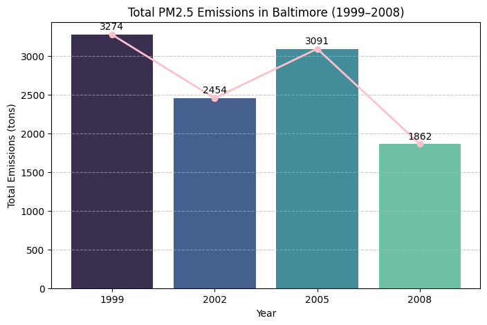

```python
baltimore_data = df_summary[df_summary["fips"] == "24510"]
baltimore_emissions = baltimore_data.groupby("year")["Emissions"].sum().reset_index()

plot_emissions_bars(baltimore_emissions, "Total PM2.5 Emissions in Baltimore (1999–2008)")
```

Thus, we can see that between 1999 and 2008, the Baltimore City emissions amount decreased from `3274` to `1862` tons. Moreover, we can also observe a jump in the number of emissions from `2454` to `3091` tons between 2002 and 2005.

## Task 3:

Of the four types of sources indicated by the type (point, nonpoint, on-road, non-road) variable, which of these four sources have seen decreases in emissions from 1999–2008 for Baltimore City? Which have seen increases in emissions from 1999–2008?

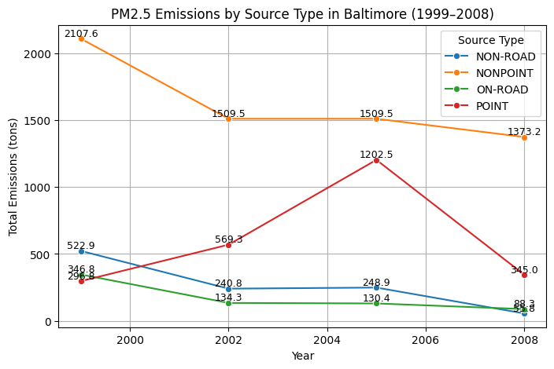

```python
baltimore_type = baltimore_data.groupby(["year", "type"])["Emissions"].sum().reset_index()


plt.figure(figsize=(8,5))
ax = sns.lineplot(data=baltimore_type, x="year", y="Emissions", hue="type", marker="o")

for line in ax.lines:
    xdata, ydata = line.get_data()
    for i in range(len(xdata)):
        ax.text(xdata[i], ydata[i], f'{ydata[i]:.1f}', color='black', ha='center', va='bottom', fontsize=9)

plt.title("PM2.5 Emissions by Source Type in Baltimore (1999–2008)")
plt.ylabel("Total Emissions (tons)")
plt.xlabel("Year")
plt.legend(title="Source Type")
plt.grid()
plt.show()
```

Thus, we can see a significant *decrease* in the amount of emissions for the types of sources `nonpoint`, `on-road` and `non-road` and a rapid *increase* in the amount of emissions for the `point` type. For this type of source the period of growth between 1999 and 2005 is especially significant. Between 2005 and 2008 we can observe a significant decrease in amounts from *1202.5* to *345* tons, but the value as of 2008 is still remains higher compared to 1999.

## Task 4:

Across the United States, how have emissions from coal combustion-related sources (source name contains substring “coal” ignoring case) changed from 1999–2008?

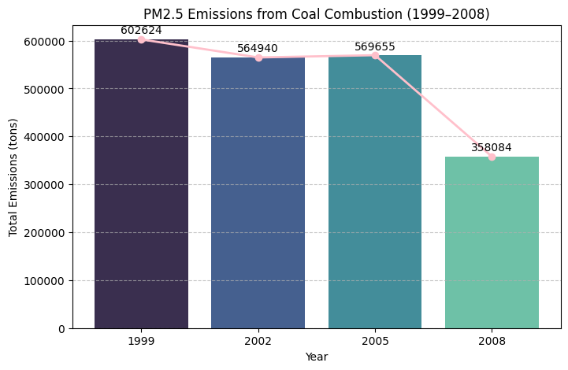

```python
coal_scc = df_class[df_class["Short.Name"].str.contains("coal", case=False, na=False)]["SCC"]
coal_data = df_summary[df_summary["SCC"].isin(coal_scc)]
coal_emissions = coal_data.groupby("year")["Emissions"].sum().reset_index()

plot_emissions_bars(coal_emissions, "PM2.5 Emissions from Coal Combustion (1999–2008)")
```

Thus, we can see that between 1999 and 2008, the emissions amount from coal combustion-related sources decreased from `602624` to `358084` tons. We can also observe a slight increase in emissions from `564940` tons in 2002 to `569655` tons in 2005.

## Task 5:

How have emissions from motor vehicle sources (source name contains substring “vehicle” ignoring case) changed from 1999–2008 in Baltimore City?

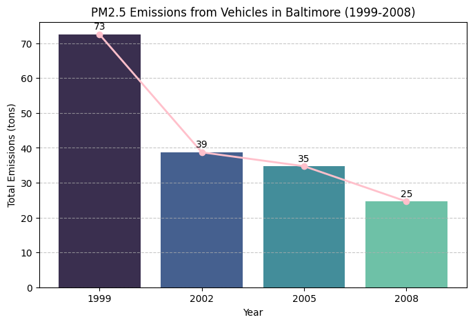

```python
vehicle_scc = df_class[df_class["Short.Name"].str.contains("vehicle", case=False, na=False)]["SCC"]
vehicle_data = df_summary[(df_summary["SCC"].isin(vehicle_scc)) & (df_summary["fips"] == "24510")]
vehicle_emissions = vehicle_data.groupby("year")["Emissions"].sum().reset_index()

plot_emissions_bars(vehicle_emissions, "PM2.5 Emissions from Vehicles in Baltimore (1999-2008)")
```

Thus, we can see that between 1999 and 2008, the emissions amount from motor vehicle sources in Baltimore City decreased from `73` to `25` tons.

## Task 6:

Compare emissions from motor vehicle sources in Baltimore City with emissions from motor vehicle sources in Los Angeles County, California (fips == "06037"). Which city has seen greater changes over time in motor vehicle emissions?

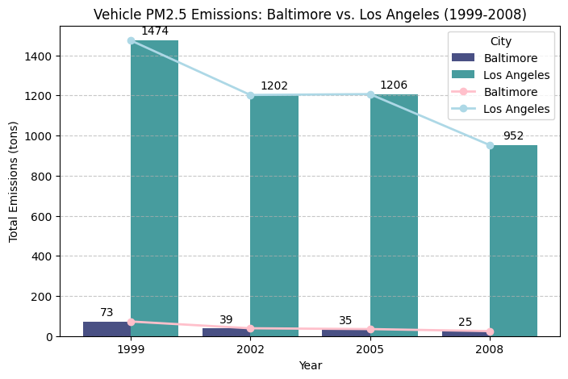

```python
la_vehicle_data = df_summary[df_summary["SCC"].isin(vehicle_scc) & (df_summary["fips"] == "06037")]
la_vehicle_emissions = la_vehicle_data.groupby("year")["Emissions"].sum().reset_index()
baltimore_vehicle_emissions = vehicle_emissions

baltimore_vehicle_emissions["City"] = "Baltimore"
la_vehicle_emissions["City"] = "Los Angeles"

combined_vehicle_data = pd.concat([baltimore_vehicle_emissions, la_vehicle_emissions])

def plot_emissions_two_cities(data, title=''):
    plt.figure(figsize=(8, 5))
    ax = sns.barplot(data=data, x="year", y="Emissions", hue="City", palette="mako")

    for p in ax.containers:
        ax.bar_label(p, fmt="%.0f", label_type="edge", fontsize=10, padding=3)

    cities = data["City"].unique()
    colors = {"Baltimore": "pink", "Los Angeles": "lightblue"}

    for city in cities:
        city_data = data[data["City"] == city].sort_values("year")
        years = city_data["year"].values
        emissions = city_data["Emissions"].values

        x_positions = list(range(len(years)))

        plt.plot(x_positions, emissions, marker="o", linestyle="-", linewidth=2, color=colors[city], label=f"{city}")

    plt.xticks(ticks=range(len(years)), labels=years)
    plt.title(title)
    plt.ylabel("Total Emissions (tons)")
    plt.xlabel("Year")
    plt.legend(title="City")
    plt.grid(axis="y", linestyle="--", alpha=0.7)
    plt.show()


plot_emissions_two_cities(combined_vehicle_data, "Vehicle PM2.5 Emissions: Baltimore vs. Los Angeles (1999-2008)")
```

By analyzing the graph above, we can see that the number of emissions in LA significantly exceeds the number of emissions in Baltimore. In both cities, we can see a decrease in emissions between 1999 and 2008, but in percentage terms, Baltimore's emissions change more significantly (by 65.8%) compared to the decrease in emissions in LA (by 35.4%).